# Exploring without the outlier

```r
# Clean the environment
rm(list=ls())

# Load libraries
library(tidyverse)
library(readxl)
library(ggpubr)
library(rstatix)
library(emmeans)
library(BayesFactor)
library(DT)
library(kableExtra)
library(assortedRFunctions)
library(TOSTER)

options(dplyr.summarise.inform = FALSE)

# Source other scripts
source('./utils/load_transform_gather.R')
```

# 1 Load and get the datasets ready

```r
outList <- load_transform_gather()

long_form_data_all_ptp_analyzed <-
    outList$long_form_data_all_ptp_analyzed
long_form_data_qc_pass_ptp_analyzed <-
    outList$long_form_data_qc_pass_ptp_analyzed

results_table_all_ptp_analyzed <-
        outList$results_table_all_ptp_analyzed
results_table_qc_pass_ptp_analyzed <-
    outList$results_table_qc_pass_ptp_analyzed
results_table_qc_pass_ptp_analyzed_gathered <-
    outList$results_table_qc_pass_ptp_analyzed_gathered

rm(outList)
```

# 2 Create the dataframes with/without outlier:

```r
# Calculate the variables for the full data
st_all_data <-
        long_form_data_qc_pass_ptp_analyzed %>%
        filter(session %in% c(1,2)) %>%
        droplevels() %>%
        group_by(experiment,
                 congruency,
                 arr_phase_1_name,
                 concept_phase_1,
                 ptp,
                 phase,
                 session) %>%
        summarise(mean = mean(correct, na.rm = TRUE)) %>%
        ungroup()



# Now for no outlier
st_no_outlier <-
        long_form_data_qc_pass_ptp_analyzed %>%
        filter(session %in% c(1,2)) %>%
        droplevels() %>%
        filter(prompt_point_idx != 1,
               prompt_point_idx != 5) %>%
        group_by(experiment,
                 congruency,
                 arr_phase_1_name,
                 concept_phase_1,
                 ptp,
                 phase,
                 session) %>%
        summarise(mean = mean(correct, na.rm = TRUE)) %>%
        ungroup()


# Calculate average for each toy separately
st_by_target <-
        long_form_data_qc_pass_ptp_analyzed %>%
        filter(session %in% c(1,2)) %>%
        droplevels() %>%
        group_by(experiment,
                 congruency,
                 arr_phase_1_name,
                 concept_phase_1,
                 ptp,
                 phase,
                 session,
                 prompt_img_name) %>%
        summarise(mean = mean(correct, na.rm = TRUE))
        # get_summary_stats(correct,type='mean')
```

```r
st <-
        merge(st_all_data,
              st_no_outlier,
              by=c('ptp',
                   'congruency',
                   'concept_phase_1',
                   'phase',
                   'session',
                   'arr_phase_1_name',
                   'experiment'),
              suffixes = c('_all_data',
                           '_no_outlier'),
              all = TRUE)
```

```r
st_long_mean_type <-
        st %>%
        pivot_longer(cols = c(mean_all_data,
                              mean_no_outlier),
                     names_to = 'mean_type',
                     values_to = 'mean_accuracy')

# Now, calculate ses 1 2 average
st_ses_1_2_mean <-
        st_long_mean_type %>%
        group_by(experiment,
                 congruency,
                 arr_phase_1_name,
                 concept_phase_1,
                 ptp,
                 phase,
                 mean_type) %>%
        summarise(ses_1_2_mean = mean(mean_accuracy, na.rm = TRUE)) %>%
        ungroup() %>%
        mutate(phase = as.character(phase))

st_phase_diff_long <-

        st_ses_1_2_mean %>%
        pivot_wider(names_from = phase,
                    names_prefix = 'phase_',
                    values_from = ses_1_2_mean) %>%
        mutate(phase_2_min_phase_1 = phase_2 - phase_1) %>%
        pivot_longer(cols = c(phase_1,
                              phase_2,
                              phase_2_min_phase_1),
                     names_to = 'phase_type',
                     values_to = 'ses_1_2_mean')

# Ses 1 2 avg for each target
st_by_target_ses_1_2_mean <-
        st_by_target %>%
        group_by(experiment,
                 congruency,
                 arr_phase_1_name,
                 concept_phase_1,
                 ptp,
                 phase,
                 prompt_img_name) %>%
        summarise(ses_1_2_mean = mean(mean, na.rm = TRUE))

# By traget, phase2 min phase1 long form. Only makes sense for the congruent data
st_by_target_phase_diff_long <-
        st_by_target_ses_1_2_mean %>%
        pivot_wider(names_from = phase,
                    names_prefix = 'phase_',
                    values_from = ses_1_2_mean) %>%
        mutate(phase_2_min_phase_1 = phase_2 - phase_1) %>%
        pivot_longer(cols = c(phase_1,
                              phase_2,
                              phase_2_min_phase_1),
                     names_to = 'phase_type',
                     values_to = 'ses_1_2_mean')
```

# 3 Plots:

## 3.1 Overall congruency

Plot the data for congruent and incongruent groups, broken down by:

- Whether its over all data or without the outlier
- Whether its experiment 1 or 2.

Conclusion: Not much learned from these plots. What is interesting is the arrangement-by-congruency interaction and if thats modulated by exclusion of the outlier.

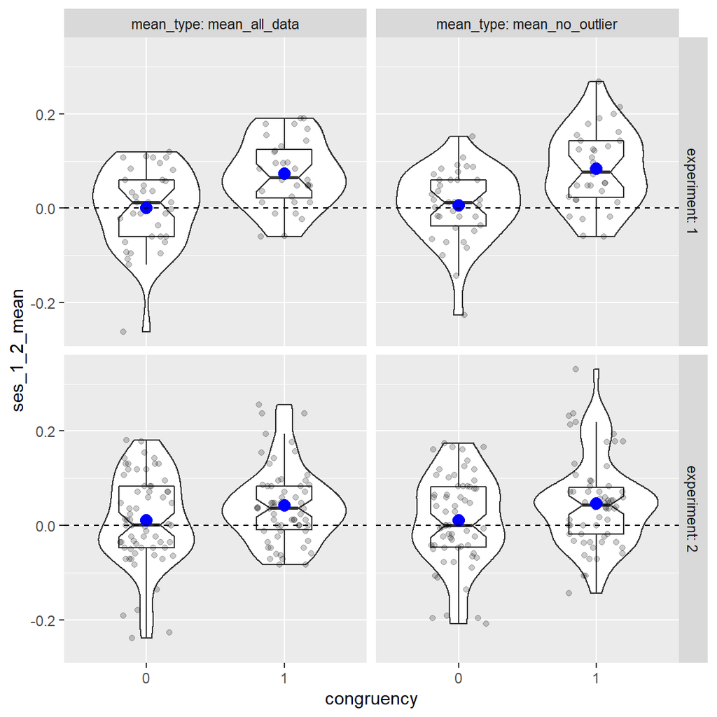

```r
st_phase_diff_long %>%
        filter(phase_type == 'phase_2_min_phase_1') %>%
        ggplot(aes(x=congruency,y=ses_1_2_mean)) +
        geom_violin() +
        geom_boxplot(notch=TRUE,
                     outlier.shape = NA,
                     width=0.4) +
        geom_jitter(width=0.2,
                    alpha=0.2,
                    height = 0) +
        stat_summary(fun=mean,
                     geom="point",
                     shape=20,
                     size=5,
                     color="blue",
                     fill="blue") +
        geom_hline(yintercept = 0, linetype = 'dashed') +
        facet_grid(experiment~mean_type,
                   labeller = label_both)
```

## 3.2 By phase:

Again, we just see what we already knew, with or without the outlier. Phase1-2 stayes the same for the incongruent, but increases for the congruent group.

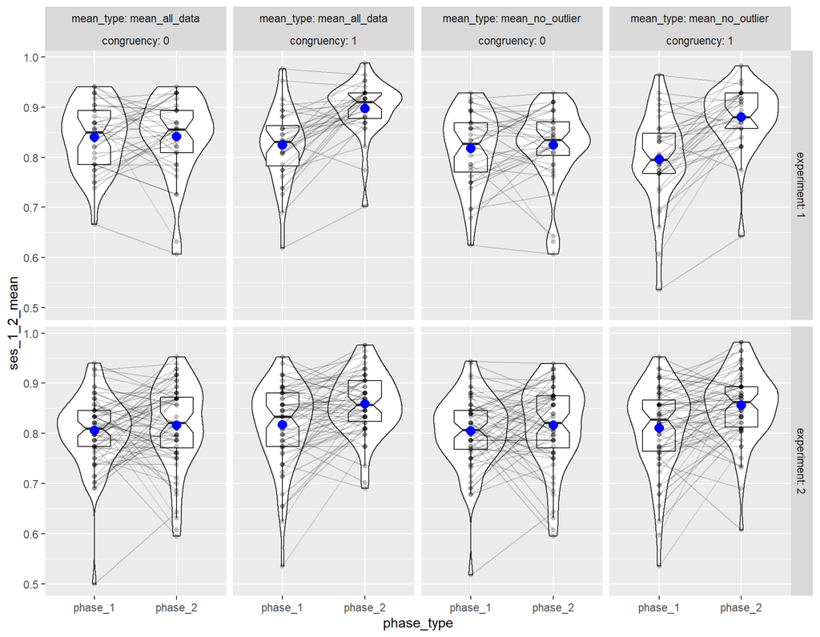

```r
st_phase_diff_long %>%
        filter(phase_type != 'phase_2_min_phase_1') %>%
        ggplot(aes(x=phase_type,y=ses_1_2_mean)) +
        geom_violin() +
        geom_boxplot(notch=TRUE,
                     outlier.shape = NA,
                     width=0.4) +
        geom_point(alpha=0.2) +
        geom_line(aes(group=ptp),
                  alpha = 0.2,
                  linetype = 'solid') +
        stat_summary(fun=mean,
                     geom="point",
                     shape=20,
                     size=5,
                     color="blue",
                     fill="blue") +
        facet_grid(experiment~mean_type+congruency,
                   labeller = label_both)
```

## 3.3 Overall congruency by arrangements:

For experiment 1:

- We can see the congruency effect disappears for Arr2, when all data is considered. Again, this is because, Arr2-to-Arr1 experiences a boost in performance, due to Sledge-PA1 in Arr1 being very easy.
- We can see the congruncy effect reappears for Arr2, when the outlier is removed. For this plot, when Congruency=1 the data hasn’t changed, because then we’re dealing with Arr2-to-Arr2, and Arr2 had no “outlier” target. Arr1 had the “outleir” Sledge-PA1. Thus, when Congruency=0, going from Arr2-to-Arr1, the Sledge-PA1 is removed from the Phase2-Arr1 data and the performance drops in Phase 2. Hence, Phase2-minus-Phase1 values drop too.

For experiment 2:

- We can see the congruency effect disappears for Arr3, when all data is considered. Presumably, this is because Arr3-to-Arr4 experiences a boost in performance due to Gingerbread man-PA2 in Arr4 being easy.
- But, excluding the outlier PA does not bring back the congruency effect for Arr3.

```
## notch went outside hinges. Try setting notch=FALSE.
## notch went outside hinges. Try setting notch=FALSE.
## notch went outside hinges. Try setting notch=FALSE.
## notch went outside hinges. Try setting notch=FALSE.
## notch went outside hinges. Try setting notch=FALSE.
```

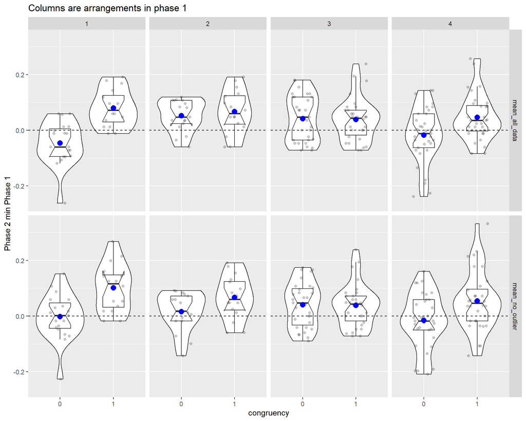

```r
st_phase_diff_long %>%
        filter(phase_type == 'phase_2_min_phase_1') %>%
        ggplot(aes(x=congruency,y=ses_1_2_mean)) +
        geom_violin() +
        geom_boxplot(notch=TRUE,
                     outlier.shape = NA,
                     width=0.4) +
        geom_jitter(width=0.2,
                    alpha=0.2,
                    height = 0) +
        stat_summary(fun=mean,
                     geom="point",
                     shape=20,
                     size=5,
                     color="blue",
                     fill="blue") +
        geom_hline(yintercept = 0, linetype = 'dashed') +
        facet_grid(mean_type~arr_phase_1_name) +
        ylab('Phase 2 min Phase 1') +
        ggtitle('Columns are arrangements in phase 1')
```

## 3.4 By phase and by arrangements:

```
## notch went outside hinges. Try setting notch=FALSE.
## notch went outside hinges. Try setting notch=FALSE.
## notch went outside hinges. Try setting notch=FALSE.
## notch went outside hinges. Try setting notch=FALSE.
## notch went outside hinges. Try setting notch=FALSE.
## notch went outside hinges. Try setting notch=FALSE.
## notch went outside hinges. Try setting notch=FALSE.
## notch went outside hinges. Try setting notch=FALSE.
```

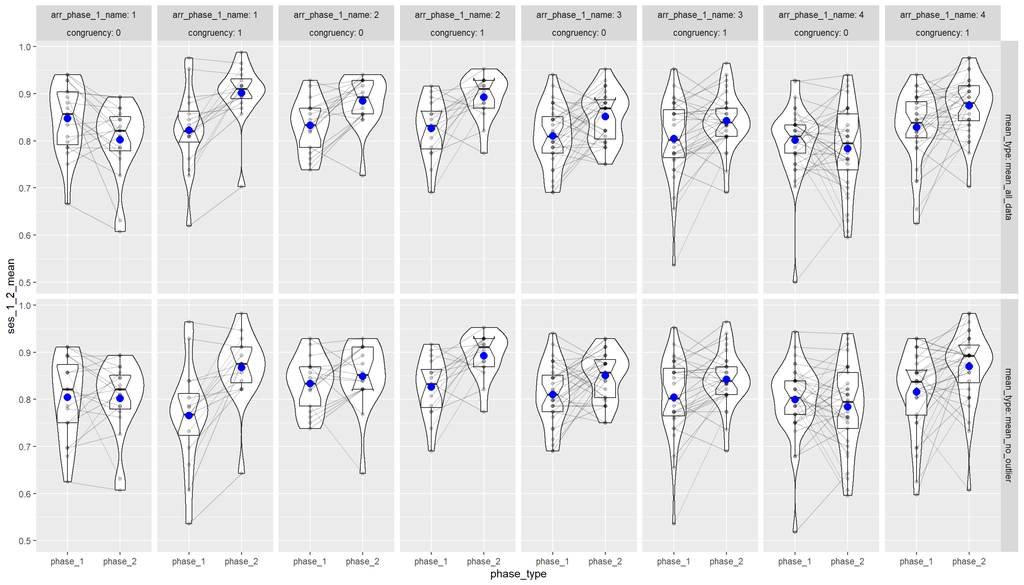

```r
st_phase_diff_long %>%
        filter(phase_type != 'phase_2_min_phase_1') %>%
        ggplot(aes(x=phase_type,y=ses_1_2_mean)) +
        geom_violin() +
        geom_boxplot(notch=TRUE,
                     outlier.shape = NA,
                     width=0.4) +
        geom_point(alpha=0.2) +
        geom_line(aes(group=ptp),
                  alpha = 0.2,
                  linetype = 'solid') +
        stat_summary(fun=mean,
                     geom="point",
                     shape=20,
                     size=5,
                     color="blue",
                     fill="blue") +
        facet_grid(mean_type~arr_phase_1_name+congruency,
                   labeller = label_both)
```

## 3.5 Sanity check plots:

Just plot all_data vs no_outlier for each phase of each group, confirming that the data doesn’t change where there is no outlier so all_data==no_outlier, and it does change where the outlier was excluded

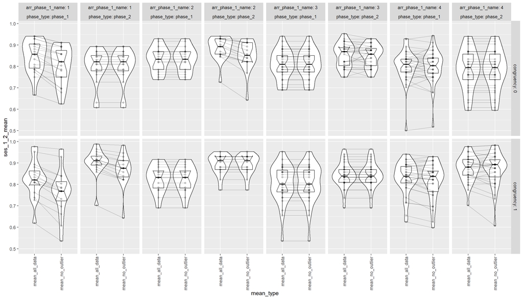

```r
st_phase_diff_long %>%
        filter(phase_type != 'phase_2_min_phase_1') %>%
        ggplot(aes(x=mean_type,y=ses_1_2_mean)) +
        geom_violin() +
        geom_boxplot(notch=TRUE,
                     outlier.shape = NA,
                     width=0.4) +
        geom_point(alpha=0.2) +
        geom_line(aes(group=ptp),
                  alpha = 0.2,
                  linetype = 'solid') +
        # stat_summary(fun=mean,
        #              geom="point",
        #              shape=20,
        #              size=5,
        #              color="blue",
        #              fill="blue") +
        facet_grid(congruency~arr_phase_1_name+phase_type,
                   labeller = label_both) +
        theme(axis.text.x = element_text(angle = 90, vjust = 0.5, hjust=1))
```

# 4 Bayes Factor calculations

We can see that, for experiment 1, starting with Arr2:

- bf_expt_1_arr_2_all_data = 0.39
- while excluding the outlier bf_expt_1_arr_2_no_outlier = 1.5.

But we also see that for experiment 2, starting with Arr3:

- bf_expt_2_arr_3_all_data = 0.26
- and is the same for bf_expt_2_arr_2_no_outlier = 0.26

```r
# Experiment 1: all data
p2_p1_congruent_1_expt_1_all_data <-
    st_phase_diff_long %>%
    filter(experiment == 1,
           congruency == 1,
           mean_type == 'mean_all_data',
           phase_type == 'phase_2_min_phase_1') %>%
    select(ses_1_2_mean) %>% .[[1]]

p2_p1_congruent_0_expt_1_all_data <-
    st_phase_diff_long %>%
    filter(experiment == 1,
           congruency == 0,
           mean_type == 'mean_all_data',
           phase_type == 'phase_2_min_phase_1') %>%
    select(ses_1_2_mean) %>% .[[1]]

bf_expt_1_all_data <-
    reportBF(ttestBF(
        p2_p1_congruent_1_expt_1_all_data,
        p2_p1_congruent_0_expt_1_all_data,
        paired = FALSE
    ),
    4)

# Experiment 1: all data, arr 1
p2_p1_congruent_1_expt_1_arr_1_all_data <-
    st_phase_diff_long %>%
    filter(experiment == 1,
           congruency == 1,
           arr_phase_1_name == 1,
           mean_type == 'mean_all_data',
           phase_type == 'phase_2_min_phase_1') %>%
    select(ses_1_2_mean) %>% .[[1]]

p2_p1_congruent_0_expt_1_arr_1_all_data <-
    st_phase_diff_long %>%
    filter(experiment == 1,
           congruency == 0,
           arr_phase_1_name == 1,
           mean_type == 'mean_all_data',
           phase_type == 'phase_2_min_phase_1') %>%
    select(ses_1_2_mean) %>% .[[1]]

bf_expt_1_arr_1_all_data <-
    reportBF(ttestBF(
        p2_p1_congruent_1_expt_1_arr_1_all_data,
        p2_p1_congruent_0_expt_1_arr_1_all_data,
        paired = FALSE
    ),
    4)

# Experiment 1: all data, arr 2
p2_p1_congruent_1_expt_1_arr_2_all_data <-
    st_phase_diff_long %>%
    filter(experiment == 1,
           congruency == 1,
           arr_phase_1_name == 2,
           mean_type == 'mean_all_data',
           phase_type == 'phase_2_min_phase_1') %>%
    select(ses_1_2_mean) %>% .[[1]]

p2_p1_congruent_0_expt_1_arr_2_all_data <-
    st_phase_diff_long %>%
    filter(experiment == 1,
           congruency == 0,
           arr_phase_1_name == 2,
           mean_type == 'mean_all_data',
           phase_type == 'phase_2_min_phase_1') %>%
    select(ses_1_2_mean) %>% .[[1]]

bf_expt_1_arr_2_all_data <-
    reportBF(ttestBF(
        p2_p1_congruent_1_expt_1_arr_2_all_data,
        p2_p1_congruent_0_expt_1_arr_2_all_data,
        paired = FALSE
    ),
    4)
```

```r
# Experiment 1: no outlier
p2_p1_congruent_1_expt_1_no_outlier <-
    st_phase_diff_long %>%
    filter(experiment == 1,
           congruency == 1,
           mean_type == 'mean_no_outlier',
           phase_type == 'phase_2_min_phase_1') %>%
    select(ses_1_2_mean) %>% .[[1]]

p2_p1_congruent_0_expt_1_no_outlier <-
    st_phase_diff_long %>%
    filter(experiment == 1,
           congruency == 0,
           mean_type == 'mean_no_outlier',
           phase_type == 'phase_2_min_phase_1') %>%
    select(ses_1_2_mean) %>% .[[1]]

bf_expt_1_no_outlier <-
    reportBF(ttestBF(
        p2_p1_congruent_1_expt_1_no_outlier,
        p2_p1_congruent_0_expt_1_no_outlier,
        paired = FALSE
    ),
    4)


# Experiment 1: no outlier, arr 1
p2_p1_congruent_1_expt_1_arr_1_no_outlier <-
    st_phase_diff_long %>%
    filter(experiment == 1,
           congruency == 1,
           arr_phase_1_name == 1,
           mean_type == 'mean_no_outlier',
           phase_type == 'phase_2_min_phase_1') %>%
    select(ses_1_2_mean) %>% .[[1]]

p2_p1_congruent_0_expt_1_arr_1_no_outlier <-
    st_phase_diff_long %>%
    filter(experiment == 1,
           congruency == 0,
           arr_phase_1_name == 1,
           mean_type == 'mean_no_outlier',
           phase_type == 'phase_2_min_phase_1') %>%
    select(ses_1_2_mean) %>% .[[1]]

bf_expt_1_arr_1_no_outlier <-
    reportBF(ttestBF(
        p2_p1_congruent_1_expt_1_arr_1_no_outlier,
        p2_p1_congruent_0_expt_1_arr_1_no_outlier,
        paired = FALSE
    ),
    4)

# Experiment 1: no outlier, arr 2
p2_p1_congruent_1_expt_1_arr_2_no_outlier <-
    st_phase_diff_long %>%
    filter(experiment == 1,
           congruency == 1,
           arr_phase_1_name == 2,
           mean_type == 'mean_no_outlier',
           phase_type == 'phase_2_min_phase_1') %>%
    select(ses_1_2_mean) %>% .[[1]]

p2_p1_congruent_0_expt_1_arr_2_no_outlier <-
    st_phase_diff_long %>%
    filter(experiment == 1,
           congruency == 0,
           arr_phase_1_name == 2,
           mean_type == 'mean_no_outlier',
           phase_type == 'phase_2_min_phase_1') %>%
    select(ses_1_2_mean) %>% .[[1]]

bf_expt_1_arr_2_no_outlier <-
    reportBF(ttestBF(
        p2_p1_congruent_1_expt_1_arr_2_no_outlier,
        p2_p1_congruent_0_expt_1_arr_2_no_outlier,
        paired = FALSE
    ),
    4)
```

```r
# Experiment 2: all data
p2_p1_congruent_1_expt_2_all_data <-
    st_phase_diff_long %>%
    filter(experiment == 2,
           congruency == 1,
           mean_type == 'mean_all_data',
           phase_type == 'phase_2_min_phase_1') %>%
    select(ses_1_2_mean) %>% .[[1]]

p2_p1_congruent_0_expt_2_all_data <-
    st_phase_diff_long %>%
    filter(experiment == 2,
           congruency == 0,
           mean_type == 'mean_all_data',
           phase_type == 'phase_2_min_phase_1') %>%
    select(ses_1_2_mean) %>% .[[1]]

bf_expt_2_all_data <-
    reportBF(ttestBF(
        p2_p1_congruent_1_expt_2_all_data,
        p2_p1_congruent_0_expt_2_all_data,
        paired = FALSE
    ),
    4)

# Experiment 2: all data, arr 3
p2_p1_congruent_1_expt_2_arr_3_all_data <-
    st_phase_diff_long %>%
    filter(experiment == 2,
           congruency == 1,
           arr_phase_1_name == 3,
           mean_type == 'mean_all_data',
           phase_type == 'phase_2_min_phase_1') %>%
    select(ses_1_2_mean) %>% .[[1]]

p2_p1_congruent_0_expt_2_arr_3_all_data <-
    st_phase_diff_long %>%
    filter(experiment == 2,
           congruency == 0,
           arr_phase_1_name == 3,
           mean_type == 'mean_all_data',
           phase_type == 'phase_2_min_phase_1') %>%
    select(ses_1_2_mean) %>% .[[1]]

bf_expt_2_arr_3_all_data <-
    reportBF(ttestBF(
        p2_p1_congruent_1_expt_2_arr_3_all_data,
        p2_p1_congruent_0_expt_2_arr_3_all_data,
        paired = FALSE
    ),
    4)

# Experiment 2: all data, arr 4
p2_p1_congruent_1_expt_2_arr_4_all_data <-
    st_phase_diff_long %>%
    filter(experiment == 2,
           congruency == 1,
           arr_phase_1_name == 4,
           mean_type == 'mean_all_data',
           phase_type == 'phase_2_min_phase_1') %>%
    select(ses_1_2_mean) %>% .[[1]]

p2_p1_congruent_0_expt_2_arr_4_all_data <-
    st_phase_diff_long %>%
    filter(experiment == 2,
           congruency == 0,
           arr_phase_1_name == 4,
           mean_type == 'mean_all_data',
           phase_type == 'phase_2_min_phase_1') %>%
    select(ses_1_2_mean) %>% .[[1]]

bf_expt_2_arr_4_all_data <-
    reportBF(ttestBF(
        p2_p1_congruent_1_expt_2_arr_4_all_data,
        p2_p1_congruent_0_expt_2_arr_4_all_data,
        paired = FALSE
    ),
    4)
```

```r
# Experiment 2: no outlier
p2_p1_congruent_1_expt_2_no_outlier <-
    st_phase_diff_long %>%
    filter(experiment == 2,
           congruency == 1,
           mean_type == 'mean_no_outlier',
           phase_type == 'phase_2_min_phase_1') %>%
    select(ses_1_2_mean) %>% .[[1]]

p2_p1_congruent_0_expt_2_no_outlier <-
    st_phase_diff_long %>%
    filter(experiment == 2,
           congruency == 0,
           mean_type == 'mean_no_outlier',
           phase_type == 'phase_2_min_phase_1') %>%
    select(ses_1_2_mean) %>% .[[1]]

bf_expt_2_no_outlier <-
    reportBF(ttestBF(
        p2_p1_congruent_1_expt_2_no_outlier,
        p2_p1_congruent_0_expt_2_no_outlier,
        paired = FALSE
    ),
    4)

# Experiment 2: no outlier, arr 3
p2_p1_congruent_1_expt_2_arr_3_no_outlier <-
    st_phase_diff_long %>%
    filter(experiment == 2,
           congruency == 1,
           arr_phase_1_name == 3,
           mean_type == 'mean_no_outlier',
           phase_type == 'phase_2_min_phase_1') %>%
    select(ses_1_2_mean) %>% .[[1]]

p2_p1_congruent_0_expt_2_arr_3_no_outlier <-
    st_phase_diff_long %>%
    filter(experiment == 2,
           congruency == 0,
           arr_phase_1_name == 3,
           mean_type == 'mean_no_outlier',
           phase_type == 'phase_2_min_phase_1') %>%
    select(ses_1_2_mean) %>% .[[1]]

bf_expt_2_arr_3_no_outlier <-
    reportBF(ttestBF(
        p2_p1_congruent_1_expt_2_arr_3_no_outlier,
        p2_p1_congruent_0_expt_2_arr_3_no_outlier,
        paired = FALSE
    ),
    4)

# Experiment 2: no outlier, arr 4
p2_p1_congruent_1_expt_2_arr_4_no_outlier <-
    st_phase_diff_long %>%
    filter(experiment == 2,
           congruency == 1,
           arr_phase_1_name == 4,
           mean_type == 'mean_no_outlier',
           phase_type == 'phase_2_min_phase_1') %>%
    select(ses_1_2_mean) %>% .[[1]]

p2_p1_congruent_0_expt_2_arr_4_no_outlier <-
    st_phase_diff_long %>%
    filter(experiment == 2,
           congruency == 0,
           arr_phase_1_name == 4,
           mean_type == 'mean_no_outlier',
           phase_type == 'phase_2_min_phase_1') %>%
    select(ses_1_2_mean) %>% .[[1]]

bf_expt_2_arr_4_no_outlier <-
    reportBF(ttestBF(
        p2_p1_congruent_1_expt_2_arr_4_no_outlier,
        p2_p1_congruent_0_expt_2_arr_4_no_outlier,
        paired = FALSE
    ),
    4)
```

## 4.1 List all the BFs

### 4.1.1 Experiment 1:

bf_expt_1_all_data = 93.0317

bf_expt_1_no_outlier = 176.6717

bf_expt_1_arr_1_all_data = 1107.5445

bf_expt_1_arr_1_no_outlier = 32.8792

bf_expt_1_arr_2_all_data = 0.3889

bf_expt_1_arr_2_no_outlier = 1.5064

### 4.1.2 Experiment 2:

bf_expt_2_all_data = 1.1654

bf_expt_2_no_outlier = 1.3582

bf_expt_2_arr_3_all_data = 0.2631

bf_expt_2_arr_3_no_outlier = 0.2622

bf_expt_2_arr_4_all_data = 6.6968

bf_expt_2_arr_4_no_outlier = 5.7032